# Project: Investigate a Dataset - [Medical Appointments - No Shows]

- Introduction
- Data Wrangling
- Exploratory Data Analysis
- Conclusions

## Introduction

### Dataset Description

> This data set represent more than 100k medical appointments in Brazil and is focused on the question of whether or not patients show up for their appointment. It contains 14 features and 110,527 observations. The dependent variable is the "No-Show" feature and it contains two unique values - NO and YES. NO means the patient did show up for the appointment while YES means the patient didn't show up for the appointment. Further details can be found [here](https://www.kaggle.com/datasets/joniarroba/noshowappointments)

> The features found in the dataset are:
> 1. PatientId - Unique ID number of the Patient
> 2. AppointmentID - Identification of each appointment
> 3. Gender - Male or Female
> 4. DataMaracaoConsulta - The day of the actual appointment, when they have to visit the doctor
> 5. DataAgendamento - The day someone called or registered the appointment, this is before appointment.
> 6. Age - How old the Patient is
> 7. Neighborhood - Where the appointment takes place
> 8. Scholarship - Whether or not the Patient is a benefiaciary of the social welfare program - **Bolsa Família**. Bolsa Família provided financial aid to poor Brazilian families. You can read more [here](https://en.wikipedia.org/wiki/Bolsa_Fam%C3%ADlia)
> 9. Hypertension - Does the Patient have hypertension?
> 10. Diabtes - Is the Patient diabetic?
> 11. Alcoholism - Is the Patient a lover of alcohol?
> 12. Handcap - Is the Patient disabled?
> 13. SMS-Recieved - Did the Patient receive any SMS prior to the actual day of the appointment?
> 14. No-Show - Did the patient show or not?

### Question(s) for Analysis

> In analyzing this dataset, some questions come to mind. In this analysis, the following questions will be answered:
> 1. Is gender an important predictor of whether people will show up or not?
> 2. Does age have any say in fixing an appointment with the doctor? Is it also correlated with the "No-Show" feature?
> 3. Did patients who received the scholarship show up more than those who didn't?
> 4. How did people show up based on the weekday and day_difference?
> 5. Did more handicaps show up for their appointments compared to the abled ones?

```python
# import all the packages needed for the analysis

import pandas as pd
import numpy as np
import matplotlib.pyplot as plt
import seaborn as sns
% matplotlib inline

#pd.set_option('display.max_rows', 20)
```

```python
# Upgrade pandas to use dataframe.explode() function.
#!pip install --upgrade pandas==0.25.0
```

## Data Wrangling

```python
# Load the data and print out the first 5 rows.
data = pd.read_csv("appointment.csv")
```

```python
data.head()
data.shape
```

```
(110527, 14)
```

The data has 110,527 rows and 14 columns

```python
data.info()
```

```
<class 'pandas.core.frame.DataFrame'>
RangeIndex: 110527 entries, 0 to 110526
Data columns (total 14 columns):
PatientId         110527 non-null float64
AppointmentID     110527 non-null int64
Gender            110527 non-null object
ScheduledDay      110527 non-null object
AppointmentDay    110527 non-null object
Age               110527 non-null int64
Neighbourhood     110527 non-null object
Scholarship       110527 non-null int64
Hipertension      110527 non-null int64
Diabetes          110527 non-null int64
Alcoholism        110527 non-null int64
Handcap           110527 non-null int64
SMS_received      110527 non-null int64
No-show           110527 non-null object
dtypes: float64(1), int64(8), object(5)
memory usage: 11.8+ MB
```

### Data Cleaning

First, we check for missing values.

```python
data.isna().sum()
```

```
PatientId         0
AppointmentID     0
Gender            0
ScheduledDay      0
AppointmentDay    0
Age               0
Neighbourhood     0
Scholarship       0
Hipertension      0
Diabetes          0
Alcoholism        0
Handcap           0
SMS_received      0
No-show           0
dtype: int64
```

The data has no missing value, so we can proceed to check the data types

```python
data.dtypes
```

```
PatientId         float64
AppointmentID       int64
Gender             object
ScheduledDay       object
AppointmentDay     object
Age                 int64
Neighbourhood      object
Scholarship         int64
Hipertension        int64
Diabetes            int64
Alcoholism          int64
Handcap             int64
SMS_received        int64
No-show            object
dtype: object
```

```python
type(data['Neighbourhood'][0])
```

```
str
```

It seems all the columns are in the correct data type. So, let's check the columns in the dataset

```python
data.columns
```

```
Index(['PatientId', 'AppointmentID', 'Gender', 'ScheduledDay',
       'AppointmentDay', 'Age', 'Neighbourhood', 'Scholarship', 'Hipertension',
       'Diabetes', 'Alcoholism', 'Handcap', 'SMS_received', 'No-show'],
      dtype='object')
```

The column names should be re-labelled for easy referencing. i.e. All the letters should be in lower case and underscores should be used to separate words

```python
col_1 = data.columns
col_2 = ['patient_id', 'appointment_id', 'gender','scheduled_day',
        'appointment_day','age','neighbourhood','scholarship','hypertension',
        'diabetes','alcoholism','handicap','sms_received','no_show']
i = 0
for j in data.columns:
    data.rename(columns = {j : col_2[i]}, inplace = True)
    i = i+1
```

```python
data.columns
```

```
Index(['patient_id', 'appointment_id', 'gender', 'scheduled_day',
       'appointment_day', 'age', 'neighbourhood', 'scholarship',
       'hypertension', 'diabetes', 'alcoholism', 'handicap', 'sms_received',
       'no_show'],
      dtype='object')
```

The columns appointment_day and scheduled_day contains a mix of date and time. Let's try and extract these features and rename as new_appointment_day, appointment_time, new_scheduled_day, and scheduled_time.

```python
a_day = []
s_day = []
for i in range(len(data['appointment_day'])):
    a_day.append(data['appointment_day'][i].split('T')[0])
    s_day.append(data['scheduled_day'][i].split('T')[0])
```

```python
data['new_appointment_day'] = a_day
data['new_scheduled_day'] = s_day
```

```python
data['new_appointment_day'].shape
```

```
(110527,)
```

```python
data['new_scheduled_day'].shape
```

```
(110527,)
```

Next, we extract the scheduled time and appointment time as follows:

```python
a_time = []
s_time = []
for i in range(len(data['appointment_day'])):
    a_time.append(data['appointment_day'][i].split('T')[1][:-1])
    s_time.append(data['scheduled_day'][i].split('T')[1][:-1])
```

```python
data['appointment_time'] = a_time
data['scheduled_time'] = s_time
```

```python
data['appointment_time'].shape
```

```
(110527,)
```

```python
data['scheduled_time'].shape
```

```
(110527,)
```

```python
data.head()
```

|  | patient_id | appointment_id | gender | scheduled_day | appointment_day | age | neighbourhood | scholarship | hypertension | diabetes | alcoholism | handicap | sms_received | no_show | new_appointment_day | new_scheduled_day | appointment_time | scheduled_time |
| --- | --- | --- | --- | --- | --- | --- | --- | --- | --- | --- | --- | --- | --- | --- | --- | --- | --- | --- |
| 0 | 2.987250e+13 | 5642903 | F | 2016-04-29T18:38:08Z | 2016-04-29T00:00:00Z | 62 | JARDIM DA PENHA | 0 | 1 | 0 | 0 | 0 | 0 | No | 2016-04-29 | 2016-04-29 | 00:00:00 | 18:38:08 |
| 1 | 5.589978e+14 | 5642503 | M | 2016-04-29T16:08:27Z | 2016-04-29T00:00:00Z | 56 | JARDIM DA PENHA | 0 | 0 | 0 | 0 | 0 | 0 | No | 2016-04-29 | 2016-04-29 | 00:00:00 | 16:08:27 |
| 2 | 4.262962e+12 | 5642549 | F | 2016-04-29T16:19:04Z | 2016-04-29T00:00:00Z | 62 | MATA DA PRAIA | 0 | 0 | 0 | 0 | 0 | 0 | No | 2016-04-29 | 2016-04-29 | 00:00:00 | 16:19:04 |
| 3 | 8.679512e+11 | 5642828 | F | 2016-04-29T17:29:31Z | 2016-04-29T00:00:00Z | 8 | PONTAL DE CAMBURI | 0 | 0 | 0 | 0 | 0 | 0 | No | 2016-04-29 | 2016-04-29 | 00:00:00 | 17:29:31 |
| 4 | 8.841186e+12 | 5642494 | F | 2016-04-29T16:07:23Z | 2016-04-29T00:00:00Z | 56 | JARDIM DA PENHA | 0 | 1 | 1 | 0 | 0 | 0 | No | 2016-04-29 | 2016-04-29 | 00:00:00 | 16:07:23 |

Now, let's check for duplicates

```python
data.duplicated().sum()
```

```
0
```

Using the duplicated function on the data as a whole shows that there are no duplicates. But a more careful look at the data suggests otherwise

```python
## Let's check for duplicates in the patient_id column
data['patient_id'].duplicated().sum()
```

```
48228
```

This means that there are 48,228 duplicated rows in the patient_id feature

```python
 data[data['patient_id'].duplicated()]
```

|  | patient_id | appointment_id | gender | scheduled_day | appointment_day | age | neighbourhood | scholarship | hypertension | diabetes | alcoholism | handicap | sms_received | no_show | new_appointment_day | new_scheduled_day | appointment_time | scheduled_time |
| --- | --- | --- | --- | --- | --- | --- | --- | --- | --- | --- | --- | --- | --- | --- | --- | --- | --- | --- |
| 27 | 1.215484e+13 | 5628345 | F | 2016-04-27T10:51:45Z | 2016-04-29T00:00:00Z | 4 | CONQUISTA | 0 | 0 | 0 | 0 | 0 | 0 | No | 2016-04-29 | 2016-04-27 | 00:00:00 | 10:51:45 |
| 154 | 1.925263e+10 | 5636933 | F | 2016-04-28T16:38:34Z | 2016-04-29T00:00:00Z | 30 | ITARARÉ | 0 | 0 | 0 | 0 | 0 | 0 | No | 2016-04-29 | 2016-04-28 | 00:00:00 | 16:38:34 |
| 288 | 2.246214e+13 | 5532908 | M | 2016-03-31T12:39:06Z | 2016-04-29T00:00:00Z | 43 | CARATOÍRA | 0 | 0 | 0 | 0 | 0 | 1 | Yes | 2016-04-29 | 2016-03-31 | 00:00:00 | 12:39:06 |
| 290 | 7.222383e+12 | 5566070 | M | 2016-04-11T09:50:18Z | 2016-04-29T00:00:00Z | 7 | CARATOÍRA | 0 | 0 | 0 | 0 | 0 | 1 | No | 2016-04-29 | 2016-04-11 | 00:00:00 | 09:50:18 |
| 316 | 1.756579e+13 | 5582867 | F | 2016-04-14T10:01:09Z | 2016-04-29T00:00:00Z | 1 | JOANA D´ARC | 0 | 0 | 0 | 0 | 0 | 0 | No | 2016-04-29 | 2016-04-14 | 00:00:00 | 10:01:09 |
| 344 | 8.218631e+11 | 5638396 | F | 2016-04-29T07:59:32Z | 2016-04-29T00:00:00Z | 23 | SÃO CRISTÓVÃO | 1 | 0 | 0 | 1 | 0 | 0 | No | 2016-04-29 | 2016-04-29 | 00:00:00 | 07:59:32 |
| 363 | 7.422796e+13 | 5575145 | F | 2016-04-12T17:12:17Z | 2016-04-29T00:00:00Z | 1 | TABUAZEIRO | 0 | 0 | 0 | 0 | 0 | 1 | No | 2016-04-29 | 2016-04-12 | 00:00:00 | 17:12:17 |
| 369 | 4.341600e+14 | 5639863 | F | 2016-04-29T09:43:15Z | 2016-04-29T00:00:00Z | 39 | PRAIA DO CANTO | 0 | 0 | 0 | 0 | 0 | 0 | No | 2016-04-29 | 2016-04-29 | 00:00:00 | 09:43:15 |
| 371 | 4.497415e+09 | 5600825 | F | 2016-04-19T11:16:27Z | 2016-04-29T00:00:00Z | 11 | BELA VISTA | 0 | 0 | 0 | 0 | 0 | 0 | No | 2016-04-29 | 2016-04-19 | 00:00:00 | 11:16:27 |
| 373 | 9.555374e+13 | 5614108 | F | 2016-04-25T10:06:33Z | 2016-04-29T00:00:00Z | 22 | ANDORINHAS | 0 | 0 | 0 | 0 | 0 | 1 | No | 2016-04-29 | 2016-04-25 | 00:00:00 | 10:06:33 |
| 374 | 2.213979e+12 | 5613288 | F | 2016-04-25T09:11:02Z | 2016-04-29T00:00:00Z | 39 | ANDORINHAS | 0 | 1 | 1 | 0 | 0 | 0 | No | 2016-04-29 | 2016-04-25 | 00:00:00 | 09:11:02 |
| 415 | 7.273892e+12 | 5601968 | F | 2016-04-19T14:02:07Z | 2016-04-29T00:00:00Z | 29 | ITARARÉ | 1 | 0 | 0 | 0 | 0 | 0 | Yes | 2016-04-29 | 2016-04-19 | 00:00:00 | 14:02:07 |
| 417 | 3.987252e+14 | 5496974 | F | 2016-03-21T15:22:17Z | 2016-04-29T00:00:00Z | 32 | ITARARÉ | 0 | 0 | 0 | 0 | 0 | 0 | No | 2016-04-29 | 2016-03-21 | 00:00:00 | 15:22:17 |
| 419 | 7.273892e+12 | 5639757 | F | 2016-04-29T09:32:22Z | 2016-04-29T00:00:00Z | 29 | ITARARÉ | 1 | 0 | 0 | 0 | 0 | 0 | No | 2016-04-29 | 2016-04-29 | 00:00:00 | 09:32:22 |
| 426 | 8.415654e+12 | 5478299 | F | 2016-03-16T14:34:20Z | 2016-04-29T00:00:00Z | 39 | ITARARÉ | 0 | 0 | 0 | 0 | 0 | 0 | No | 2016-04-29 | 2016-03-16 | 00:00:00 | 14:34:20 |
| 436 | 2.616716e+12 | 5639908 | F | 2016-04-29T09:47:49Z | 2016-04-29T00:00:00Z | 9 | MARIA ORTIZ | 0 | 0 | 0 | 0 | 0 | 0 | No | 2016-04-29 | 2016-04-29 | 00:00:00 | 09:47:49 |
| 464 | 9.166776e+14 | 5617014 | F | 2016-04-25T15:13:27Z | 2016-04-29T00:00:00Z | 35 | MARUÍPE | 1 | 0 | 0 | 0 | 0 | 1 | No | 2016-04-29 | 2016-04-25 | 00:00:00 | 15:13:27 |
| 466 | 5.161239e+12 | 5629304 | F | 2016-04-27T13:16:02Z | 2016-04-29T00:00:00Z | 49 | CONSOLAÇÃO | 0 | 0 | 0 | 0 | 0 | 0 | No | 2016-04-29 | 2016-04-27 | 00:00:00 | 13:16:02 |
| 470 | 7.272334e+13 | 5571892 | M | 2016-04-12T09:44:02Z | 2016-04-29T00:00:00Z | 15 | NOVA PALESTINA | 0 | 0 | 0 | 0 | 0 | 0 | No | 2016-04-29 | 2016-04-12 | 00:00:00 | 09:44:02 |
| 486 | 3.884285e+12 | 5472443 | F | 2016-03-15T14:32:30Z | 2016-04-29T00:00:00Z | 50 | CONQUISTA | 0 | 0 | 0 | 0 | 0 | 0 | No | 2016-04-29 | 2016-03-15 | 00:00:00 | 14:32:30 |
| 500 | 3.265242e+12 | 5483275 | F | 2016-03-17T11:09:11Z | 2016-04-29T00:00:00Z | 12 | ITARARÉ | 0 | 0 | 0 | 0 | 0 | 0 | Yes | 2016-04-29 | 2016-03-17 | 00:00:00 | 11:09:11 |
| 502 | 6.642337e+12 | 5616140 | M | 2016-04-25T13:33:53Z | 2016-04-29T00:00:00Z | 23 | ITARARÉ | 0 | 0 | 0 | 0 | 0 | 0 | No | 2016-04-29 | 2016-04-25 | 00:00:00 | 13:33:53 |
| 514 | 2.541248e+14 | 5638790 | F | 2016-04-29T08:25:09Z | 2016-04-29T00:00:00Z | 38 | BONFIM | 0 | 0 | 0 | 0 | 0 | 0 | No | 2016-04-29 | 2016-04-29 | 00:00:00 | 08:25:09 |
| 544 | 8.749945e+11 | 5642644 | F | 2016-04-29T16:35:26Z | 2016-04-29T00:00:00Z | 64 | BONFIM | 0 | 1 | 0 | 0 | 0 | 0 | No | 2016-04-29 | 2016-04-29 | 00:00:00 | 16:35:26 |
| 547 | 1.971196e+13 | 5536363 | F | 2016-04-01T08:33:12Z | 2016-04-29T00:00:00Z | 21 | MARIA ORTIZ | 0 | 0 | 0 | 0 | 0 | 1 | Yes | 2016-04-29 | 2016-04-01 | 00:00:00 | 08:33:12 |
| 548 | 2.621687e+11 | 5609931 | F | 2016-04-20T17:49:35Z | 2016-04-29T00:00:00Z | 37 | MARIA ORTIZ | 0 | 0 | 0 | 0 | 0 | 1 | Yes | 2016-04-29 | 2016-04-20 | 00:00:00 | 17:49:35 |
| 554 | 4.916356e+12 | 5521769 | M | 2016-03-29T12:40:26Z | 2016-04-29T00:00:00Z | 40 | CENTRO | 0 | 0 | 0 | 0 | 0 | 0 | Yes | 2016-04-29 | 2016-03-29 | 00:00:00 | 12:40:26 |
| 562 | 7.422889e+13 | 5526114 | F | 2016-03-30T10:23:08Z | 2016-04-29T00:00:00Z | 53 | DO MOSCOSO | 0 | 0 | 0 | 0 | 0 | 1 | No | 2016-04-29 | 2016-03-30 | 00:00:00 | 10:23:08 |
| 564 | 5.559567e+14 | 5523026 | F | 2016-03-29T15:47:46Z | 2016-04-29T00:00:00Z | 50 | PARQUE MOSCOSO | 0 | 0 | 0 | 0 | 0 | 1 | No | 2016-04-29 | 2016-03-29 | 00:00:00 | 15:47:46 |
| 573 | 9.624983e+13 | 5590495 | M | 2016-04-15T14:20:43Z | 2016-04-29T00:00:00Z | 64 | SANTA LÚCIA | 0 | 1 | 1 | 0 | 0 | 1 | No | 2016-04-29 | 2016-04-15 | 00:00:00 | 14:20:43 |
| ... | ... | ... | ... | ... | ... | ... | ... | ... | ... | ... | ... | ... | ... | ... | ... | ... | ... | ... |
| 110485 | 4.865334e+12 | 5762486 | F | 2016-06-02T07:49:14Z | 2016-06-06T00:00:00Z | 34 | SANTA LUÍZA | 0 | 0 | 0 | 0 | 0 | 0 | No | 2016-06-06 | 2016-06-02 | 00:00:00 | 07:49:14 |
| 110486 | 3.184153e+14 | 5788099 | F | 2016-06-08T11:14:23Z | 2016-06-08T00:00:00Z | 60 | MARIA ORTIZ | 0 | 0 | 0 | 0 | 0 | 0 | No | 2016-06-08 | 2016-06-08 | 00:00:00 | 11:14:23 |
| 110487 | 1.891645e+12 | 5786423 | M | 2016-06-08T08:24:51Z | 2016-06-08T00:00:00Z | 20 | MARIA ORTIZ | 0 | 0 | 0 | 0 | 0 | 0 | No | 2016-06-08 | 2016-06-08 | 00:00:00 | 08:24:51 |
| 110488 | 7.935892e+14 | 5760379 | M | 2016-06-01T14:47:12Z | 2016-06-01T00:00:00Z | 76 | MARIA ORTIZ | 0 | 0 | 0 | 0 | 0 | 0 | No | 2016-06-01 | 2016-06-01 | 00:00:00 | 14:47:12 |
| 110492 | 6.456342e+14 | 5786741 | M | 2016-06-08T08:50:19Z | 2016-06-08T00:00:00Z | 33 | MARIA ORTIZ | 0 | 1 | 0 | 0 | 0 | 0 | Yes | 2016-06-08 | 2016-06-08 | 00:00:00 | 08:50:19 |
| 110494 | 2.895817e+14 | 5779073 | F | 2016-06-06T17:44:14Z | 2016-06-08T00:00:00Z | 38 | MARIA ORTIZ | 0 | 0 | 0 | 0 | 0 | 0 | No | 2016-06-08 | 2016-06-06 | 00:00:00 | 17:44:14 |
| 110496 | 8.544295e+13 | 5779046 | F | 2016-06-06T17:35:38Z | 2016-06-08T00:00:00Z | 37 | MARIA ORTIZ | 0 | 1 | 0 | 0 | 0 | 0 | Yes | 2016-06-08 | 2016-06-06 | 00:00:00 | 17:35:38 |
| 110497 | 7.935892e+14 | 5757745 | M | 2016-06-01T09:46:33Z | 2016-06-01T00:00:00Z | 76 | MARIA ORTIZ | 0 | 0 | 0 | 0 | 0 | 0 | No | 2016-06-01 | 2016-06-01 | 00:00:00 | 09:46:33 |
| 110498 | 9.433654e+13 | 5787655 | F | 2016-06-08T10:21:14Z | 2016-06-08T00:00:00Z | 59 | MARIA ORTIZ | 0 | 0 | 0 | 0 | 0 | 0 | No | 2016-06-08 | 2016-06-08 | 00:00:00 | 10:21:14 |
| 110499 | 8.219692e+14 | 5757697 | F | 2016-06-01T09:42:56Z | 2016-06-01T00:00:00Z | 66 | MARIA ORTIZ | 0 | 1 | 1 | 0 | 0 | 0 | No | 2016-06-01 | 2016-06-01 | 00:00:00 | 09:42:56 |
| 110500 | 4.434384e+14 | 5787233 | F | 2016-06-08T09:35:13Z | 2016-06-08T00:00:00Z | 59 | MARIA ORTIZ | 0 | 0 | 0 | 0 | 0 | 0 | No | 2016-06-08 | 2016-06-08 | 00:00:00 | 09:35:13 |
| 110502 | 7.316229e+14 | 5787937 | F | 2016-06-08T10:50:42Z | 2016-06-08T00:00:00Z | 22 | GOIABEIRAS | 0 | 0 | 0 | 0 | 0 | 0 | No | 2016-06-08 | 2016-06-08 | 00:00:00 | 10:50:42 |
| 110503 | 2.362182e+13 | 5759473 | F | 2016-06-01T13:00:36Z | 2016-06-01T00:00:00Z | 64 | SOLON BORGES | 0 | 0 | 0 | 0 | 0 | 0 | No | 2016-06-01 | 2016-06-01 | 00:00:00 | 13:00:36 |
| 110504 | 9.947983e+12 | 5788052 | F | 2016-06-08T11:06:21Z | 2016-06-08T00:00:00Z | 4 | MARIA ORTIZ | 0 | 0 | 0 | 0 | 0 | 0 | No | 2016-06-08 | 2016-06-08 | 00:00:00 | 11:06:21 |
| 110505 | 5.667344e+13 | 5758455 | F | 2016-06-01T10:45:50Z | 2016-06-01T00:00:00Z | 55 | MARIA ORTIZ | 0 | 0 | 0 | 0 | 0 | 0 | No | 2016-06-01 | 2016-06-01 | 00:00:00 | 10:45:50 |
| 110506 | 8.973883e+11 | 5758779 | M | 2016-06-01T11:09:20Z | 2016-06-01T00:00:00Z | 5 | MARIA ORTIZ | 0 | 0 | 0 | 0 | 0 | 0 | No | 2016-06-01 | 2016-06-01 | 00:00:00 | 11:09:20 |
| 110507 | 4.769462e+14 | 5786918 | F | 2016-06-08T09:04:18Z | 2016-06-08T00:00:00Z | 0 | MARIA ORTIZ | 0 | 0 | 0 | 0 | 0 | 0 | No | 2016-06-08 | 2016-06-08 | 00:00:00 | 09:04:18 |
| 110508 | 9.433654e+13 | 5757656 | F | 2016-06-01T09:41:00Z | 2016-06-01T00:00:00Z | 59 | MARIA ORTIZ | 0 | 0 | 0 | 0 | 0 | 0 | No | 2016-06-01 | 2016-06-01 | 00:00:00 | 09:41:00 |
| 110509 | 4.952968e+14 | 5786750 | M | 2016-06-08T08:50:51Z | 2016-06-08T00:00:00Z | 33 | MARIA ORTIZ | 0 | 0 | 0 | 0 | 0 | 0 | No | 2016-06-08 | 2016-06-08 | 00:00:00 | 08:50:51 |
| 110510 | 2.362182e+13 | 5757587 | F | 2016-06-01T09:35:48Z | 2016-06-01T00:00:00Z | 64 | SOLON BORGES | 0 | 0 | 0 | 0 | 0 | 0 | No | 2016-06-01 | 2016-06-01 | 00:00:00 | 09:35:48 |
| 110514 | 2.695685e+12 | 5786567 | F | 2016-06-08T08:35:31Z | 2016-06-08T00:00:00Z | 58 | MARIA ORTIZ | 0 | 0 | 0 | 0 | 0 | 0 | No | 2016-06-08 | 2016-06-08 | 00:00:00 | 08:35:31 |
| 110515 | 6.456342e+14 | 5778621 | M | 2016-06-06T15:58:05Z | 2016-06-08T00:00:00Z | 33 | MARIA ORTIZ | 0 | 1 | 0 | 0 | 0 | 0 | Yes | 2016-06-08 | 2016-06-06 | 00:00:00 | 15:58:05 |
| 110516 | 6.923772e+13 | 5780205 | F | 2016-06-07T07:45:16Z | 2016-06-08T00:00:00Z | 37 | MARIA ORTIZ | 0 | 0 | 0 | 0 | 0 | 0 | Yes | 2016-06-08 | 2016-06-07 | 00:00:00 | 07:45:16 |
| 110517 | 5.574942e+12 | 5780122 | F | 2016-06-07T07:38:34Z | 2016-06-07T00:00:00Z | 19 | MARIA ORTIZ | 0 | 0 | 0 | 0 | 0 | 0 | No | 2016-06-07 | 2016-06-07 | 00:00:00 | 07:38:34 |
| 110519 | 6.542388e+13 | 5630447 | F | 2016-04-27T15:23:14Z | 2016-06-07T00:00:00Z | 22 | MARIA ORTIZ | 0 | 0 | 0 | 0 | 0 | 1 | No | 2016-06-07 | 2016-04-27 | 00:00:00 | 15:23:14 |
| 110521 | 3.635534e+13 | 5651072 | F | 2016-05-03T08:23:40Z | 2016-06-07T00:00:00Z | 53 | MARIA ORTIZ | 0 | 0 | 0 | 0 | 0 | 1 | No | 2016-06-07 | 2016-05-03 | 00:00:00 | 08:23:40 |
| 110522 | 2.572134e+12 | 5651768 | F | 2016-05-03T09:15:35Z | 2016-06-07T00:00:00Z | 56 | MARIA ORTIZ | 0 | 0 | 0 | 0 | 0 | 1 | No | 2016-06-07 | 2016-05-03 | 00:00:00 | 09:15:35 |
| 110523 | 3.596266e+12 | 5650093 | F | 2016-05-03T07:27:33Z | 2016-06-07T00:00:00Z | 51 | MARIA ORTIZ | 0 | 0 | 0 | 0 | 0 | 1 | No | 2016-06-07 | 2016-05-03 | 00:00:00 | 07:27:33 |
| 110525 | 9.213493e+13 | 5630323 | F | 2016-04-27T15:09:23Z | 2016-06-07T00:00:00Z | 38 | MARIA ORTIZ | 0 | 0 | 0 | 0 | 0 | 1 | No | 2016-06-07 | 2016-04-27 | 00:00:00 | 15:09:23 |
| 110526 | 3.775115e+14 | 5629448 | F | 2016-04-27T13:30:56Z | 2016-06-07T00:00:00Z | 54 | MARIA ORTIZ | 0 | 0 | 0 | 0 | 0 | 1 | No | 2016-06-07 | 2016-04-27 | 00:00:00 | 13:30:56 |

48228 rows × 18 columns

Let's inspect the first duplicated patient_id (index 27)

```python
data[data['patient_id'] == data['patient_id'][27]]
```

|  | patient_id | appointment_id | gender | scheduled_day | appointment_day | age | neighbourhood | scholarship | hypertension | diabetes | alcoholism | handicap | sms_received | no_show | new_appointment_day | new_scheduled_day | appointment_time | scheduled_time |
| --- | --- | --- | --- | --- | --- | --- | --- | --- | --- | --- | --- | --- | --- | --- | --- | --- | --- | --- |
| 21 | 1.215484e+13 | 5628338 | F | 2016-04-27T10:50:45Z | 2016-04-29T00:00:00Z | 4 | CONQUISTA | 0 | 0 | 0 | 0 | 0 | 0 | Yes | 2016-04-29 | 2016-04-27 | 00:00:00 | 10:50:45 |
| 27 | 1.215484e+13 | 5628345 | F | 2016-04-27T10:51:45Z | 2016-04-29T00:00:00Z | 4 | CONQUISTA | 0 | 0 | 0 | 0 | 0 | 0 | No | 2016-04-29 | 2016-04-27 | 00:00:00 | 10:51:45 |
| 51197 | 1.215484e+13 | 5646344 | F | 2016-05-02T11:16:02Z | 2016-05-05T00:00:00Z | 4 | CONQUISTA | 0 | 0 | 0 | 0 | 0 | 0 | No | 2016-05-05 | 2016-05-02 | 00:00:00 | 11:16:02 |
| 51200 | 1.215484e+13 | 5676612 | F | 2016-05-09T16:02:48Z | 2016-05-19T00:00:00Z | 4 | CONQUISTA | 0 | 0 | 0 | 0 | 0 | 0 | Yes | 2016-05-19 | 2016-05-09 | 00:00:00 | 16:02:48 |
| 68608 | 1.215484e+13 | 5616843 | F | 2016-04-25T14:53:10Z | 2016-05-05T00:00:00Z | 4 | CONQUISTA | 0 | 0 | 0 | 0 | 0 | 1 | No | 2016-05-05 | 2016-04-25 | 00:00:00 | 14:53:10 |
| 68610 | 1.215484e+13 | 5676609 | F | 2016-05-09T16:02:03Z | 2016-05-19T00:00:00Z | 4 | CONQUISTA | 0 | 0 | 0 | 0 | 0 | 0 | Yes | 2016-05-19 | 2016-05-09 | 00:00:00 | 16:02:03 |

- The result above suggests there are patients that booked multiple appointments with the doctor.
- They showed up for some while they didn't show up for others.
- The data above also shows repeated data across several features. This can really mess up our analysis

To avoid unnecssary complications, let's drop rows with duplicate patient_ids

```python
v = data['patient_id'].drop_duplicates()
v.index
```

```
Int64Index([     0,      1,      2,      3,      4,      5,      6,      7,
                 8,      9,
            ...
            110491, 110493, 110495, 110501, 110511, 110512, 110513, 110518,
            110520, 110524],
           dtype='int64', length=62299)
```

```python
data = data.iloc[v.index]
```

```python
data.shape
```

```
(62299, 18)
```

Now, let's confirm whether or not there are still duplicates left

```python
data['patient_id'].duplicated().sum()
```

```
0
```

Let's inspect our dataset once again and drop those features that are not needed.

```python
data.head()
```

|  | patient_id | appointment_id | gender | scheduled_day | appointment_day | age | neighbourhood | scholarship | hypertension | diabetes | alcoholism | handicap | sms_received | no_show | new_appointment_day | new_scheduled_day | appointment_time | scheduled_time |
| --- | --- | --- | --- | --- | --- | --- | --- | --- | --- | --- | --- | --- | --- | --- | --- | --- | --- | --- |
| 0 | 2.987250e+13 | 5642903 | F | 2016-04-29T18:38:08Z | 2016-04-29T00:00:00Z | 62 | JARDIM DA PENHA | 0 | 1 | 0 | 0 | 0 | 0 | No | 2016-04-29 | 2016-04-29 | 00:00:00 | 18:38:08 |
| 1 | 5.589978e+14 | 5642503 | M | 2016-04-29T16:08:27Z | 2016-04-29T00:00:00Z | 56 | JARDIM DA PENHA | 0 | 0 | 0 | 0 | 0 | 0 | No | 2016-04-29 | 2016-04-29 | 00:00:00 | 16:08:27 |
| 2 | 4.262962e+12 | 5642549 | F | 2016-04-29T16:19:04Z | 2016-04-29T00:00:00Z | 62 | MATA DA PRAIA | 0 | 0 | 0 | 0 | 0 | 0 | No | 2016-04-29 | 2016-04-29 | 00:00:00 | 16:19:04 |
| 3 | 8.679512e+11 | 5642828 | F | 2016-04-29T17:29:31Z | 2016-04-29T00:00:00Z | 8 | PONTAL DE CAMBURI | 0 | 0 | 0 | 0 | 0 | 0 | No | 2016-04-29 | 2016-04-29 | 00:00:00 | 17:29:31 |
| 4 | 8.841186e+12 | 5642494 | F | 2016-04-29T16:07:23Z | 2016-04-29T00:00:00Z | 56 | JARDIM DA PENHA | 0 | 1 | 1 | 0 | 0 | 0 | No | 2016-04-29 | 2016-04-29 | 00:00:00 | 16:07:23 |

- We already extracted new_appointed_day, new_scheduled_day, appointment_time, scheduled_time from scheduled_day and appointment_day, so we can drop those two safely
- We can also drop the appointment_id as it is of no use to our analysis

```python
data.drop(['appointment_id','scheduled_day','appointment_day'], axis=1, inplace = True)
```

```python
data['new_scheduled_day'] = pd.to_datetime(data['new_scheduled_day'])
data['new_appointment_day'] = pd.to_datetime(data['new_appointment_day'])

## converting the above features from string to datetime
```

```python
data['appointment_month'] = data['new_appointment_day'].apply(lambda x:x.month)
data['scheduled_month'] = data['new_scheduled_day'].apply(lambda x:x.month)

## Extracting out the month from both features above
```

```python
data['appointment_weekday'] = data['new_appointment_day'].apply(lambda x:x.dayofweek)

## Extracting out the weekday 'new appointment_day'
```

```python
data['scheduled_weekday'] = data['new_scheduled_day'].apply(lambda x:x.dayofweek)

## Extracting out the month from both 'new_scheduled_day'
```

```python
dow_dict = {0:"Monday",1:"Tuesday",2:"Wednesday",3:"Thursday",4:"Friday",5:"Saturday",6:"Sunday"}
data['appointment_weekday']= data['appointment_weekday'].map(dow_dict)
data['scheduled_weekday']= data['scheduled_weekday'].map(dow_dict)

## We map the values to the specific days of the week
```

```python
data['day_diff'] = data['new_appointment_day'] - data['new_scheduled_day']

## let's check for the number of days between the appointment date and the scheduled date
```

```python
data['day_diff'].head()
```

```
0   0 days
1   0 days
2   0 days
3   0 days
4   0 days
Name: day_diff, dtype: timedelta64[ns]
```

```python
## we see the day_diff features has days along with every value, let's try and separate the values from the string

data['day_diff']=data['day_diff'].astype(str)
data['day_diff']=data['day_diff'].apply(lambda x:x.split(" ")[0])
data['day_diff']=data['day_diff'].astype(int)
```

```python
data.columns
```

```
Index(['patient_id', 'gender', 'age', 'neighbourhood', 'scholarship',
       'hypertension', 'diabetes', 'alcoholism', 'handicap', 'sms_received',
       'no_show', 'new_appointment_day', 'new_scheduled_day',
       'appointment_time', 'scheduled_time', 'appointment_month',
       'scheduled_month', 'appointment_weekday', 'scheduled_weekday',
       'day_diff'],
      dtype='object')
```

Let's drop some features since we have extracted the features we need for our analysis ..This will help us avoid redundancy of features

```python
data.drop(["new_appointment_day", "new_scheduled_day", "appointment_time", "scheduled_time"], axis=1, inplace = True)
```

```python
data.describe()
```

|  | patient_id | age | scholarship | hypertension | diabetes | alcoholism | handicap | sms_received | appointment_month | scheduled_month | day_diff |
| --- | --- | --- | --- | --- | --- | --- | --- | --- | --- | --- | --- |
| count | 6.229900e+04 | 62299.000000 | 62299.000000 | 62299.000000 | 62299.000000 | 62299.000000 | 62299.000000 | 62299.000000 | 62299.000000 | 62299.000000 | 62299.000000 |
| mean | 1.471711e+14 | 36.704891 | 0.092907 | 0.196504 | 0.070884 | 0.024174 | 0.020113 | 0.327357 | 5.122795 | 4.720220 | 11.131142 |
| std | 2.549091e+14 | 23.531372 | 0.290304 | 0.397357 | 0.256633 | 0.153590 | 0.155056 | 0.469252 | 0.450949 | 0.737164 | 16.375275 |
| min | 3.921784e+04 | -1.000000 | 0.000000 | 0.000000 | 0.000000 | 0.000000 | 0.000000 | 0.000000 | 4.000000 | 1.000000 | -1.000000 |
| 25% | 4.176937e+12 | 17.000000 | 0.000000 | 0.000000 | 0.000000 | 0.000000 | 0.000000 | 0.000000 | 5.000000 | 4.000000 | 0.000000 |
| 50% | 3.198866e+13 | 36.000000 | 0.000000 | 0.000000 | 0.000000 | 0.000000 | 0.000000 | 0.000000 | 5.000000 | 5.000000 | 4.000000 |
| 75% | 9.484809e+13 | 56.000000 | 0.000000 | 0.000000 | 0.000000 | 0.000000 | 0.000000 | 1.000000 | 5.000000 | 5.000000 | 17.000000 |
| max | 9.999816e+14 | 115.000000 | 1.000000 | 1.000000 | 1.000000 | 1.000000 | 4.000000 | 1.000000 | 6.000000 | 12.000000 | 179.000000 |

It can be seen from the above that the minimum age is -1, which is not meant to be so. The min_day_diff is also -1. Let's try to drop those rows

```python
data.query('age<0')
# find rows where age is less than zero
```

|  | patient_id | gender | age | neighbourhood | scholarship | hypertension | diabetes | alcoholism | handicap | sms_received | no_show | appointment_month | scheduled_month | appointment_weekday | scheduled_weekday | day_diff |
| --- | --- | --- | --- | --- | --- | --- | --- | --- | --- | --- | --- | --- | --- | --- | --- | --- |
| 99832 | 4.659432e+14 | F | -1 | ROMÃO | 0 | 0 | 0 | 0 | 0 | 0 | No | 6 | 6 | Monday | Monday | 0 |

```python
data.drop(axis=0,index=99832,inplace=True)
# drop the rows using the index value
```

```python
data.query('day_diff<0')
# find rows where day difference is less than 0
```

|  | patient_id | gender | age | neighbourhood | scholarship | hypertension | diabetes | alcoholism | handicap | sms_received | no_show | appointment_month | scheduled_month | appointment_weekday | scheduled_weekday | day_diff |
| --- | --- | --- | --- | --- | --- | --- | --- | --- | --- | --- | --- | --- | --- | --- | --- | --- |
| 72362 | 3.787482e+12 | M | 7 | TABUAZEIRO | 0 | 0 | 0 | 0 | 0 | 0 | Yes | 5 | 5 | Tuesday | Wednesday | -1 |

```python
data.drop(axis=0,index=72362,inplace=True)
# drop the row using the index value
```

```python
data.reset_index(inplace=True)
data.drop(['index'], axis = 1, inplace = True)
data.head()
```

|  | patient_id | gender | age | neighbourhood | scholarship | hypertension | diabetes | alcoholism | handicap | sms_received | no_show | appointment_month | scheduled_month | appointment_weekday | scheduled_weekday | day_diff |
| --- | --- | --- | --- | --- | --- | --- | --- | --- | --- | --- | --- | --- | --- | --- | --- | --- |
| 0 | 2.987250e+13 | F | 62 | JARDIM DA PENHA | 0 | 1 | 0 | 0 | 0 | 0 | No | 4 | 4 | Friday | Friday | 0 |
| 1 | 5.589978e+14 | M | 56 | JARDIM DA PENHA | 0 | 0 | 0 | 0 | 0 | 0 | No | 4 | 4 | Friday | Friday | 0 |
| 2 | 4.262962e+12 | F | 62 | MATA DA PRAIA | 0 | 0 | 0 | 0 | 0 | 0 | No | 4 | 4 | Friday | Friday | 0 |
| 3 | 8.679512e+11 | F | 8 | PONTAL DE CAMBURI | 0 | 0 | 0 | 0 | 0 | 0 | No | 4 | 4 | Friday | Friday | 0 |
| 4 | 8.841186e+12 | F | 56 | JARDIM DA PENHA | 0 | 1 | 1 | 0 | 0 | 0 | No | 4 | 4 | Friday | Friday | 0 |

```python
data['appointment_weekday'].value_counts()
```

```
Tuesday      14849
Wednesday    13633
Monday       13165
Friday       11071
Thursday      9553
Saturday        26
Name: appointment_weekday, dtype: int64
```

```python
data['scheduled_weekday'].value_counts()
```

```
Tuesday      15140
Wednesday    13497
Monday       12808
Friday       10660
Thursday     10181
Saturday        11
Name: scheduled_weekday, dtype: int64
```

since we are dealing more with knowing the possible reasons why people didnt show up for the appointment, the "scheduled_weekday", "scheduled_day_month" can be dropped. They both really don't help our analysis and the questions we want to answer.

```python
data.drop(['scheduled_weekday','scheduled_month'], axis=1,inplace=True)
```

```python
data.columns
```

```
Index(['patient_id', 'gender', 'age', 'neighbourhood', 'scholarship',
       'hypertension', 'diabetes', 'alcoholism', 'handicap', 'sms_received',
       'no_show', 'appointment_month', 'appointment_weekday', 'day_diff'],
      dtype='object')
```

```python
data.shape
```

```
(62297, 14)
```

#### **Now, our data is in the right shape for analysis**

## Exploratory Data Analysis

```python
data.head()
```

|  | patient_id | gender | age | neighbourhood | scholarship | hypertension | diabetes | alcoholism | handicap | sms_received | no_show | appointment_month | appointment_weekday | day_diff |
| --- | --- | --- | --- | --- | --- | --- | --- | --- | --- | --- | --- | --- | --- | --- |
| 0 | 2.987250e+13 | F | 62 | JARDIM DA PENHA | 0 | 1 | 0 | 0 | 0 | 0 | No | 4 | Friday | 0 |
| 1 | 5.589978e+14 | M | 56 | JARDIM DA PENHA | 0 | 0 | 0 | 0 | 0 | 0 | No | 4 | Friday | 0 |
| 2 | 4.262962e+12 | F | 62 | MATA DA PRAIA | 0 | 0 | 0 | 0 | 0 | 0 | No | 4 | Friday | 0 |
| 3 | 8.679512e+11 | F | 8 | PONTAL DE CAMBURI | 0 | 0 | 0 | 0 | 0 | 0 | No | 4 | Friday | 0 |
| 4 | 8.841186e+12 | F | 56 | JARDIM DA PENHA | 0 | 1 | 1 | 0 | 0 | 0 | No | 4 | Friday | 0 |

```python
data.describe()
```

|  | patient_id | age | scholarship | hypertension | diabetes | alcoholism | handicap | sms_received | appointment_month | day_diff |
| --- | --- | --- | --- | --- | --- | --- | --- | --- | --- | --- |
| count | 6.229700e+04 | 62297.000000 | 62297.000000 | 62297.000000 | 62297.000000 | 62297.000000 | 62297.000000 | 62297.000000 | 62297.000000 | 62297.000000 |
| mean | 1.471683e+14 | 36.705973 | 0.092910 | 0.196510 | 0.070886 | 0.024175 | 0.020113 | 0.327367 | 5.122783 | 11.131515 |
| std | 2.549094e+14 | 23.530964 | 0.290308 | 0.397362 | 0.256637 | 0.153592 | 0.155059 | 0.469256 | 0.450942 | 16.375405 |
| min | 3.921784e+04 | 0.000000 | 0.000000 | 0.000000 | 0.000000 | 0.000000 | 0.000000 | 0.000000 | 4.000000 | 0.000000 |
| 25% | 4.176940e+12 | 17.000000 | 0.000000 | 0.000000 | 0.000000 | 0.000000 | 0.000000 | 0.000000 | 5.000000 | 0.000000 |
| 50% | 3.198866e+13 | 36.000000 | 0.000000 | 0.000000 | 0.000000 | 0.000000 | 0.000000 | 0.000000 | 5.000000 | 4.000000 |
| 75% | 9.484790e+13 | 56.000000 | 0.000000 | 0.000000 | 0.000000 | 0.000000 | 0.000000 | 1.000000 | 5.000000 | 17.000000 |
| max | 9.999816e+14 | 115.000000 | 1.000000 | 1.000000 | 1.000000 | 1.000000 | 4.000000 | 1.000000 | 6.000000 | 179.000000 |

[output not shown]

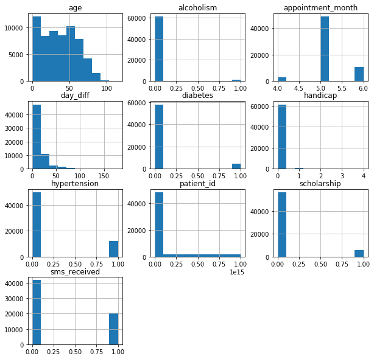

```python
## checking the distribution of all the features in the dataset
data.hist(figsize=(10,10))
```

```
Text(0.5,1,'Appointment Overall No-Show Percentage')
```

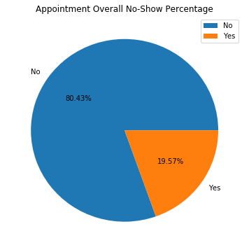

```python
# Make Pie Chart showing overall percentage of No-Show Appointments.

plt.figure(figsize=(6,6))
pie_chart_data = data.groupby("no_show").count()
labels = ['No','Yes']
plt.pie(data=pie_chart_data,x="gender",labels= labels,autopct='%.2f%%')
plt.legend()
plt.title('Appointment Overall No-Show Percentage')
```

- Overall, about 20% of patients did not show up at their appointment.
- Over 80% of patients showed up at their appointment.

#### 1. Is gender an important predictor of whether people will show up or not?

```python
data['gender'].value_counts()
```

```
F    40045
M    22252
Name: gender, dtype: int64
```

```
Text(0.5,0,'Gender')
```

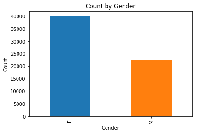

```python
data['gender'].value_counts().plot(kind= 'bar')
plt.title("Count by Gender")
plt.ylabel("Count")
plt.xlabel("Gender")
```

since more females are represented in this sample, let's get the percentage of men and women that showed up relative to both genders

```python
x =data.groupby(['gender','no_show']).count()['patient_id']
```

```python
## Percentage of women who came for the appointment
(x[0]/(x[0]+x[1]))*100
```

```
80.45199150955176
```

```python
## Percentage of men who came for the appointment
(x[2]/(x[2]+x[3]))*100
```

```
80.388279705195046
```

The values above are really close, which means gender is not a very good predictor of whether people will show up or not

```
Text(0,0.5,'Number of patients')
```

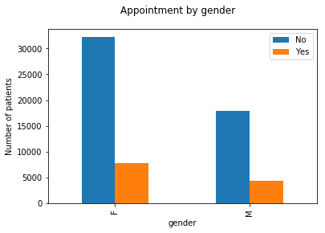

```python
dat =data.groupby(['gender','no_show']).count()
dat["patient_id"].unstack().plot(kind='bar',stacked=False)
plt.legend(["No",'Yes']) #Clarify the features of the drawing
plt.suptitle('Appointment by gender') #title
plt.ylabel('Number of patients') # A label to the y axis
```

#### 2. Does age have any say in fixing an appointment with the doctor? Is it also correlated with the "No-Show" feature?

```python
data.describe()
```

|  | patient_id | age | scholarship | hypertension | diabetes | alcoholism | handicap | sms_received | appointment_month | day_diff |
| --- | --- | --- | --- | --- | --- | --- | --- | --- | --- | --- |
| count | 6.229700e+04 | 62297.000000 | 62297.000000 | 62297.000000 | 62297.000000 | 62297.000000 | 62297.000000 | 62297.000000 | 62297.000000 | 62297.000000 |
| mean | 1.471683e+14 | 36.705973 | 0.092910 | 0.196510 | 0.070886 | 0.024175 | 0.020113 | 0.327367 | 5.122783 | 11.131515 |
| std | 2.549094e+14 | 23.530964 | 0.290308 | 0.397362 | 0.256637 | 0.153592 | 0.155059 | 0.469256 | 0.450942 | 16.375405 |
| min | 3.921784e+04 | 0.000000 | 0.000000 | 0.000000 | 0.000000 | 0.000000 | 0.000000 | 0.000000 | 4.000000 | 0.000000 |
| 25% | 4.176940e+12 | 17.000000 | 0.000000 | 0.000000 | 0.000000 | 0.000000 | 0.000000 | 0.000000 | 5.000000 | 0.000000 |
| 50% | 3.198866e+13 | 36.000000 | 0.000000 | 0.000000 | 0.000000 | 0.000000 | 0.000000 | 0.000000 | 5.000000 | 4.000000 |
| 75% | 9.484790e+13 | 56.000000 | 0.000000 | 0.000000 | 0.000000 | 0.000000 | 0.000000 | 1.000000 | 5.000000 | 17.000000 |
| max | 9.999816e+14 | 115.000000 | 1.000000 | 1.000000 | 1.000000 | 1.000000 | 4.000000 | 1.000000 | 6.000000 | 179.000000 |

```python
# Convert Age into Age Groups based on the minimum value, 25th, 50th, 75th percetile, and maximum value
bin_edges = [0, 17, 36, 56, 116]
labels = ['Child','Teen','Adult','Senior']
data['age_group'] = pd.cut(data['age'], bins=bin_edges, labels=labels, include_lowest= True, right= False)
```

```python
age_data = data.groupby(['age_group','no_show']).count()
```

```python
pd.crosstab([data['age_group'],data['no_show']], data['gender'])
```

| age_group | gender no_show | F | M |
| --- | --- | --- | --- |
| Child | No | 6177 | 6098 |
|  | Yes | 1593 | 1556 |
| Teen | No | 8113 | 3347 |
|  | Yes | 2525 | 1023 |
| Adult | No | 9051 | 3979 |
|  | Yes | 2122 | 1052 |
| Senior | No | 8876 | 4464 |
|  | Yes | 1588 | 733 |

```
Text(0,0.5,'Count')
```

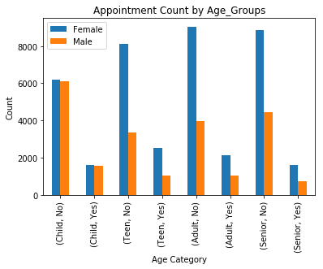

```python
gd = pd.crosstab([data['age_group'],data['no_show']], data['gender'])

gd.plot(kind='bar',stacked=False)
plt.legend(["Female",'Male']) #Clarify the features of the drawing
plt.title('Appointment Count by Age_Groups')
plt.xlabel('Age Category')
plt.ylabel("Count")
```

```
Text(0,0.5,'Count')
```

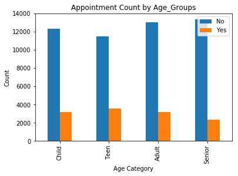

```python
age_data["patient_id"].unstack().plot(kind='bar',stacked=False)
plt.legend(["No",'Yes']) #Clarify the features of the drawing
plt.title('Appointment Count by Age_Groups')
plt.xlabel('Age Category')
plt.ylabel("Count")
```

The analysis above suggests that apart from the children, who maybe are still being taken care of by their parents, people tend to show up as their age increases. The younger ones don't show up the most while the older ones show up more

#### 3. Did patients who received the scholarship show up more than those who didn't?

```python
scholar = data.groupby(['no_show','scholarship'])['gender'].count()
scholar
```

```
no_show  scholarship
No       0              45624
         1               4481
Yes      0              10885
         1               1307
Name: gender, dtype: int64
```

```
Text(0,0.5,'Count')
```

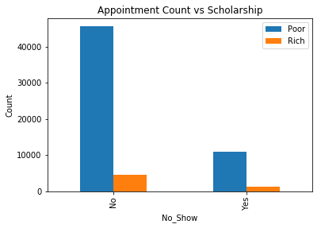

```python
##  Let's see if scholarship affects whether a patient will show up or not
scholar.unstack().plot(kind='bar',stacked=False)
plt.legend(["Poor",'Rich']) #Clarify the features of the drawing
plt.title('Appointment Count vs Scholarship')
plt.xlabel('No_Show')
plt.ylabel('Count')
```

#### 4. How did people show up based on the weekday and day_difference?

```python
agn_data = pd.crosstab([data["appointment_weekday"],data['gender']], data['no_show'])
```

```
Text(0,0.5,'Count')
```

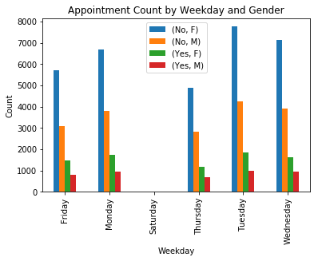

```python
agn_data.unstack().plot(kind='bar',stacked=False)
plt.legend() #Clarify the features of the drawing
plt.title('Appointment Count by Weekday and Gender')
plt.xlabel('Weekday')
plt.ylabel('Count')
```

- More patients turn up on Mondays to Wednesdays (mostly on Tuesdays)

```
Text(0,0.5,'Count')
```

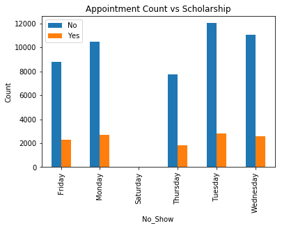

```python
sch = pd.crosstab(data["appointment_weekday"], data['no_show'])
sch.plot(kind='bar',stacked=False)
plt.legend() #Clarify the features of the drawing
plt.title('Appointment Count vs Scholarship')
plt.xlabel('No_Show')
plt.ylabel('Count')
```

Patients don't tend to show up on weekends, while Monday, Tuesday, and Wednesday has the highest number of turnouts

By day_difference, let's divide the day_diff into categories

```python
bin_edges = [0, 4, 17, 180]
labels = ['Early','Late','Very_Late']
data['day_category'] = pd.cut(data['day_diff'], bins=bin_edges, labels=labels, include_lowest= True, right= False)
```

```python
day_data = data.groupby(['day_category','no_show']).count()
```

```
Text(0,0.5,'Count')
```

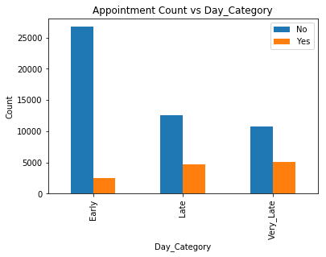

```python
day_data['patient_id'].unstack().plot(kind='bar',stacked=False)
plt.legend() #Clarify the features of the drawing
plt.title('Appointment Count vs Day_Category')
plt.xlabel('Day_Category')
plt.ylabel('Count')
```

From the visualization above, we see that the more days pass by, the higher the tendency of patients not to show up. Most patients show up early

#### 5. Did more handicaps show up for their appointments compared to the abled ones?

First, we classify patients with either diabetes, hypertension or handicap as unhealthy and healthy if otherwise

```python
coll = []
for i in range(len(data['handicap'])):
    if data['handicap'][i] + data['diabetes'][i] + data['hypertension'][i] > 0:
        coll.append('Unhealthy')
    else:
        coll.append('Healthy')
```

```python
data['disability'] = coll
```

```python
pd.crosstab([data['disability'],data['day_category']],data['no_show'])
```

| disability | no_show day_category | No | Yes |
| --- | --- | --- | --- |
| Healthy | Early | 20790 | 1891 |
|  | Late | 9313 | 3749 |
|  | Very_Late | 8637 | 4264 |
| Unhealthy | Early | 5943 | 644 |
|  | Late | 3251 | 901 |
|  | Very_Late | 2171 | 743 |

```
Text(0,0.5,'Count')
```

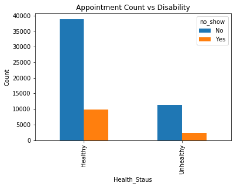

```python
healthy_data = pd.crosstab(data['disability'], data['no_show'])
healthy_data.plot(kind = 'bar', stacked = False)
plt.title('Appointment Count vs Disability')
plt.xlabel('Health_Staus')
plt.ylabel('Count')
```

This image above shows that more healthy people didnt show up for the appointment compared to the disabled ones. In other words, those with at least an illness turn up more for their appointment

```
Text(0,0.5,'Count')
```

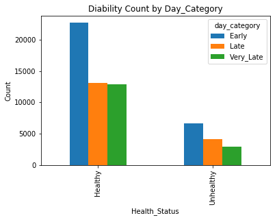

```python
healthy_data = pd.crosstab(data['disability'], data['day_category'])
healthy_data.plot(kind = 'bar', stacked = False)
plt.title('Diability Count by Day_Category')
plt.xlabel('Health_Status')
plt.ylabel('Count')
```

Less disabled pepple were late/very late to their appointments compared to the completely healthy ones This validates our intial conclusion

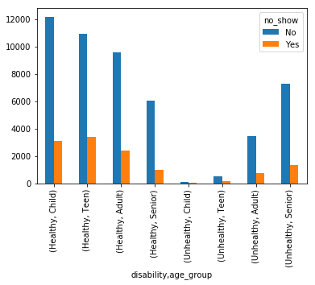

```python
healthy_data = pd.crosstab([data['disability'], data['age_group']], data['no_show'])
healthy_data.plot(kind = 'bar', stacked = False)
```

## Conclusion

The data that has been analyzed has some limitations. Some of them are:

- The dataset is small compared to the total population of Brazil.Therefore, it might not be representative of the entire population
- Many patient_ids are not unique. This means some patients registered more than once and book the same appoitment date on the same scheduled date. This anomaly in the data is why unique patient_ids are retained.
- The time under which the observations are recorded is too short to make any justifiable and meritable conclusion. All the dates considered are only in 2016 and the highest differemce between scheduled_date and appointment_date was 180days (6months)
- We created other features to help the data analysis process.

```python
from subprocess import call
call(['python', '-m', 'nbconvert', 'Investigate_a_Dataset.ipynb'])
```

```
0
```